## 探討心血管疾病與糖尿病之關係

醫技三 B04404013 吳嘉峻

因心血管疾病的死亡的人數(圖一):台灣於1994年實施全民健保，2000年被保人涵蓋率達96%，對於病人就醫幫忙很大，間接對於心血管診療的發展有貢獻，但由於近年來國人的飲食習慣，導致心血管死亡人數的上升 因糖尿病而死亡的人數(圖二):由於國人的飲食習慣，加上台灣國人平均壽命的延長，導致因糖尿病而死亡人數有上升的趨勢

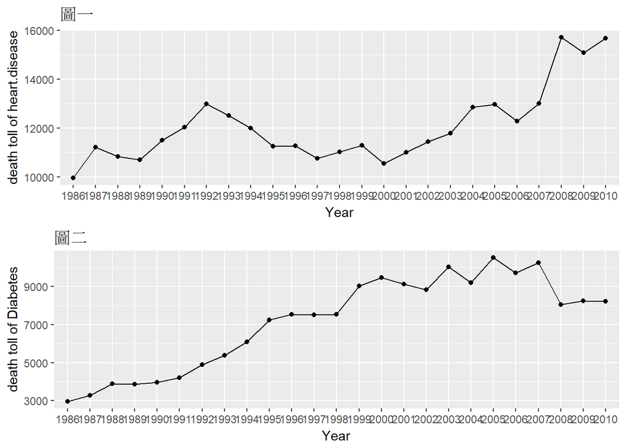

## 進一步確認此兩種疾病佔所有死亡人數的比例變化

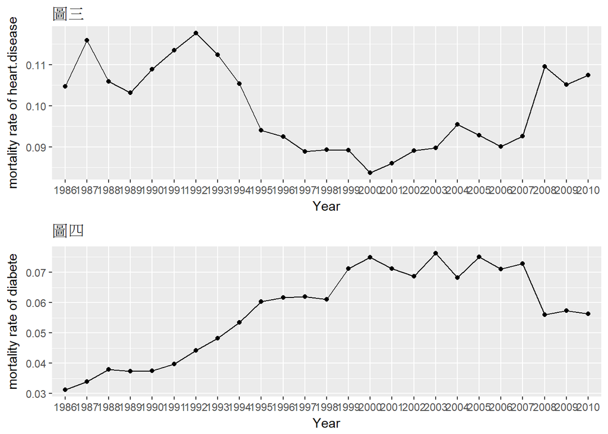

## 探討心血管疾病死亡人數與糖尿病死亡人數的關係

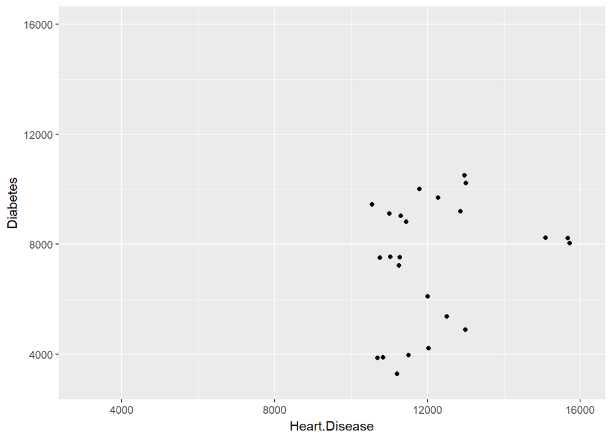

## 探討心血管疾病占死亡比例與糖尿病死亡占死亡比例之關係

兩者成反比: 由於糖尿病患者有很大的機率會併發心血管疾病，可以知道糖尿病與心血管疾病的患者有很大的比例會重複，而這些病患可能死於心血管疾病或者糖尿病，故因心血管疾病死亡的人數比例上升，因糖尿病死亡的人數比例就會下降

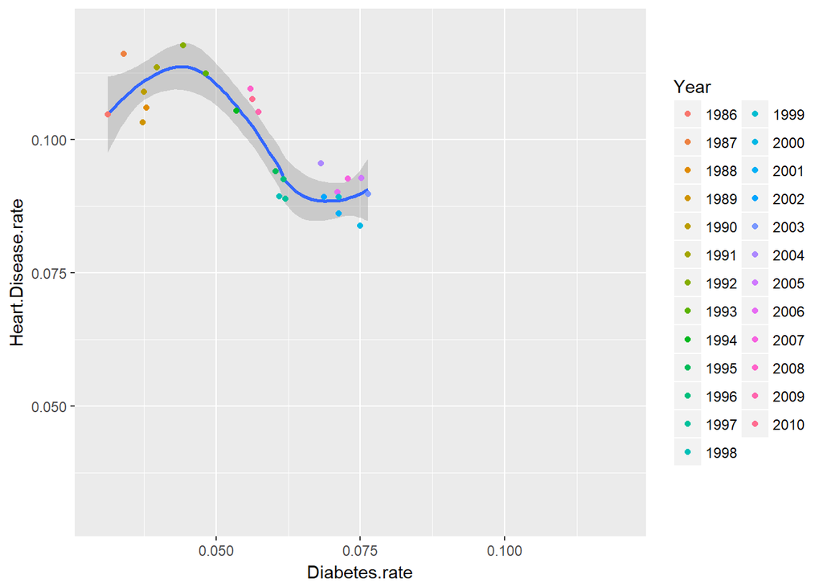

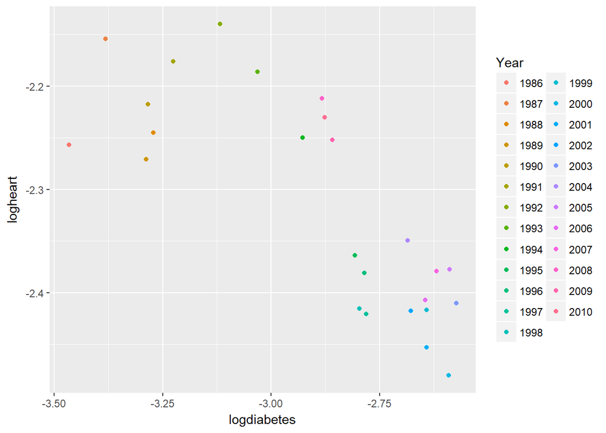